# (Dataset Exploration Title)

## Univariate Exploration

> In this section, investigate distributions of individual variables. If you see unusual points or outliers, take a deeper look to clean things up and prepare yourself to look at relationships between variables.

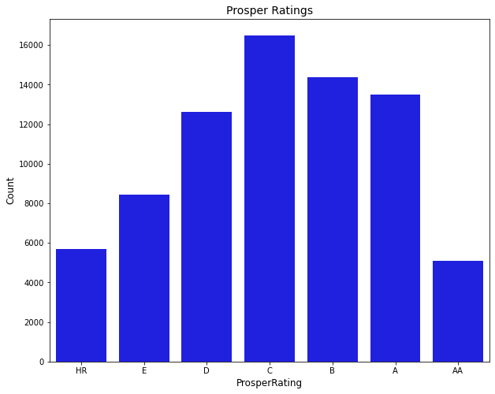

```python
plt.figure(figsize=(10,8))
plt.subplot(1,1,1)
sb.countplot(data=df, x='ProsperRating (Alpha)', color='blue');
plt.title('Prosper Ratings', fontsize=14)
plt.ylabel('Count', fontsize=12)
plt.xlabel('ProsperRating', fontsize=12);
```

C and B are the most popular ratings.

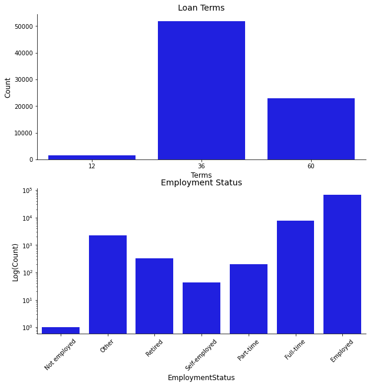

```python
plt.figure(figsize=(10,10))
plt.subplot(2,1,2)
sb.countplot(data=df, x='EmploymentStatus', color='blue');
plt.title('Employment Status', fontsize=14)
plt.ylabel('Log(Count)', fontsize=12)
plt.xlabel('EmploymentStatus', fontsize=12);
plt.yscale('log')
plt.xticks(rotation=45)


plt.subplot(2,1,1)
sb.countplot(data=df, x='Term', color='blue')
plt.title('Loan Terms', fontsize=14)
plt.ylabel('Count', fontsize=12)
plt.xlabel('Terms', fontsize=12);
sb.despine()
```

most borrowers are employed or full-time. The length of most of the loans are 36 months.

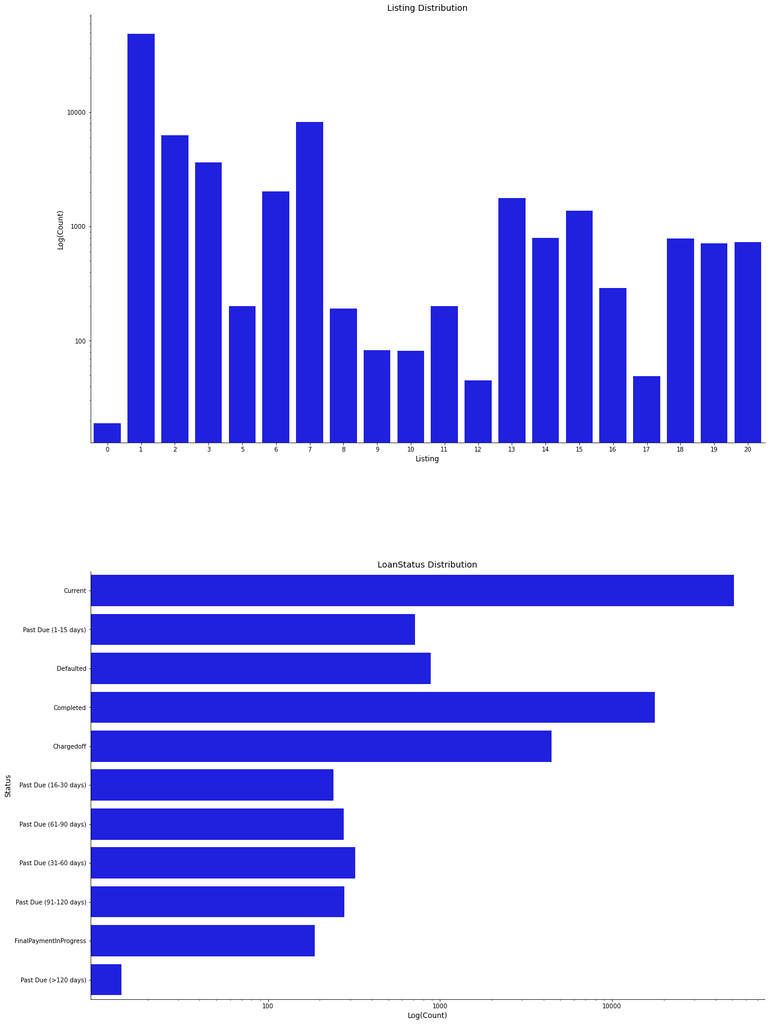

```python
plt.figure(figsize=(20,30))
plt.subplot(2,1,1)
sb.countplot(data=df, x='ListingCategory (numeric)', color='blue');
plt.yscale('log')
plt.yticks([100,1000,10000], ['100', '1000', '10000'])
plt.title('Listing Distribution', fontsize=14)
plt.xlabel('Listing', fontsize=12)
plt.ylabel('Log(Count)', fontsize=12)
plt.subplots_adjust(hspace = 0.3)

plt.subplot(2,1,2)
sb.countplot(data=df, y='LoanStatus', color='blue');
#plt.xticks(rotation=45)
plt.xscale('log')
plt.xticks([100,1000,10000], ['100', '1000', '10000'])
plt.title('LoanStatus Distribution', fontsize=14)
plt.xlabel('Log(Count)', fontsize=12)
plt.ylabel('Status', fontsize=12);
sb.despine()
```

The category of the listing that the borrower selected when posting their listing: 0 - Not Available, 1 - Debt Consolidation, 2 - Home Improvement, 3 - Business, 4 - Personal Loan, 5 - Student Use, 6 - Auto, 7- Other, 8 - Baby&Adoption, 9 - Boat, 10 - Cosmetic Procedure, 11 - Engagement Ring, 12 - Green Loans, 13 - Household Expenses, 14 - Large Purchases, 15 - Medical/Dental, 16 -Motorcycle, 17 - RV, 18 - Taxes, 19 - Vacation, 20 - Wedding Loans

the Debt Consildation (1), Home Improvement (2) and Other (7) are the most popular listings. Most of the Loans have 'Current' status then 'Completed' status.

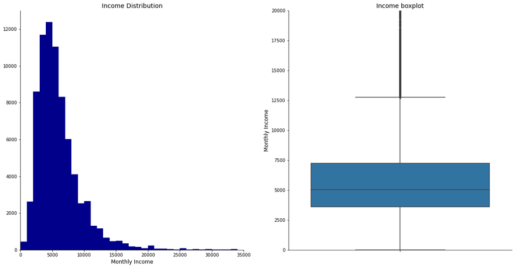

```python
plt.figure(figsize=(20,10))
plt.subplot(1,2,1)
bins = np.arange(0, df.StatedMonthlyIncome.max(), 1000)
plt.hist(data=df, x='StatedMonthlyIncome', bins=bins, color='darkblue');
plt.xlim(0, 35000);
plt.title('Income Distribution', fontsize=14)
plt.xlabel('Monthly Income', fontsize=12)

plt.subplot(1,2,2)
sb.boxplot(data=df, y='StatedMonthlyIncome');
plt.title('Income boxplot', fontsize=14)
plt.ylim(0, 20000)
plt.ylabel('Monthly Income', fontsize=12);
sb.despine()
```

It appears that the monthly income distribution is a right-skewed distribution with about mean 5000. There are a lot of outliers according to the boxplot which needs more investigating.

```python
# Reduce outliers of Monthly Income by cut them
# tried 20000 , 17500 and 15000
print(100*df[df['StatedMonthlyIncome']>15000].shape[0] / df.shape[0])
df = df[df['StatedMonthlyIncome']<=15000]
```

```
2.5257163850110214
```

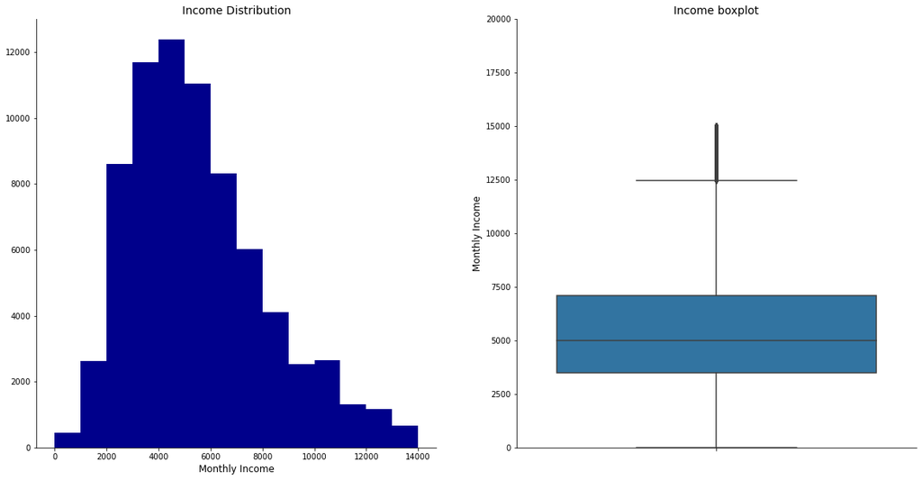

```python
plt.figure(figsize=(20,10))
plt.subplot(1,2,1)
bins = np.arange(0, df.StatedMonthlyIncome.max(), 1000)
plt.hist(data=df, x='StatedMonthlyIncome', bins=bins, color='darkblue');
#plt.xlim(0, 35000);
plt.title('Income Distribution', fontsize=14)
plt.xlabel('Monthly Income', fontsize=12)

plt.subplot(1,2,2)
sb.boxplot(data=df, y='StatedMonthlyIncome');
plt.title('Income boxplot', fontsize=14)
plt.ylim(0, 20000)
plt.ylabel('Monthly Income', fontsize=12);
sb.despine()
```

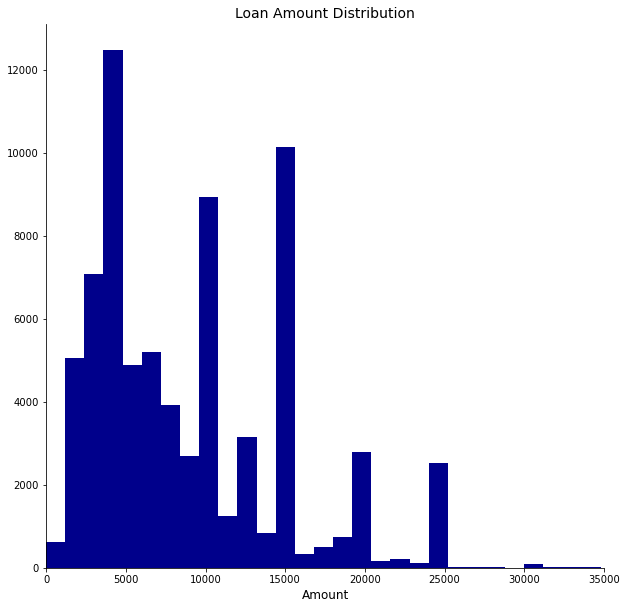

```python
plt.figure(figsize=(10,10))
bins = np.arange(0, df.LoanOriginalAmount.max(), 1200)
plt.hist(data=df, x='LoanOriginalAmount', bins=bins, color='darkblue')
plt.title('Loan Amount Distribution', fontsize=14)
plt.xlim(0, 35000);
plt.xlabel('Amount', fontsize=12);
sb.despine()
```

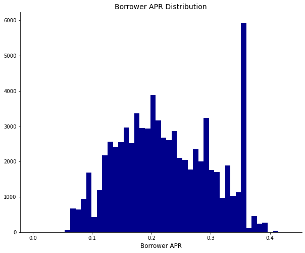

```python
plt.figure(figsize=(10, 8))
bins = np.arange(0, df.BorrowerAPR.max()+0.01, 0.009)
plt.hist(data=df, x='BorrowerAPR', bins=bins, color='darkblue');
plt.title('Borrower APR Distribution', fontsize=14)
plt.xlabel('Borrower APR', fontsize=12);
sb.despine()
```

### Of the features you investigated, were there any unusual distributions? Did you perform any operations on the data to tidy, adjust, or change the form of the data? If so, why did you do this?

> I used log(count) to close the gap between numbers as there are very large numbers can dominate the plot.

> For MonthlyIncome distribution, It was right-skewed with many outliers, some had large income amounts compared to the rest of the borrowers which can be made up, and thus I removed most of them since they represented around 2.5% of the data.

## Bivariate Exploration

> In this section, investigate relationships between pairs of variables in your data. Make sure the variables that you cover here have been introduced in some fashion in the previous section (univariate exploration).

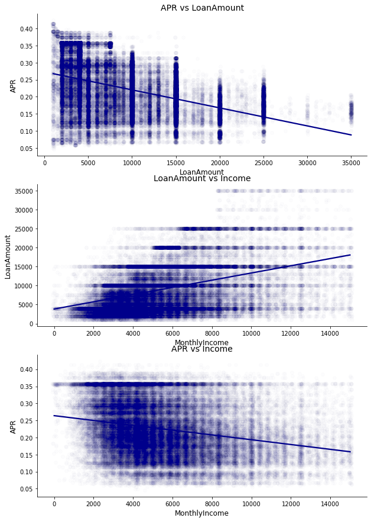

```python
plt.figure(figsize=(10,15))
plt.subplot(3,1,1)
sb.regplot(data=df, x='LoanOriginalAmount', y='BorrowerAPR', color='darkblue', x_jitter=100,
          scatter_kws={'alpha':0.01}, fit_reg=True)
plt.title('APR vs LoanAmount', fontsize=14)
plt.xlabel('LoanAmount', fontsize=12)
plt.ylabel('APR', fontsize=12);

plt.subplot(3,1,2)
sb.regplot(data=df, x='StatedMonthlyIncome', y='LoanOriginalAmount', color='darkblue', x_jitter=100,
          scatter_kws={'alpha':0.01}, fit_reg=True)
plt.title('LoanAmount vs Income', fontsize=14)
plt.xlabel('MonthlyIncome', fontsize=12)
plt.ylabel('LoanAmount', fontsize=12);
sb.despine()

plt.subplot(3,1,3)
sb.regplot(data=df, x='StatedMonthlyIncome', y='BorrowerAPR', color='darkblue', x_jitter=100,
          scatter_kws={'alpha':0.01}, fit_reg=True)
plt.title('APR vs Income', fontsize=14)
plt.xlabel('MonthlyIncome', fontsize=12)
plt.ylabel('APR', fontsize=12);
sb.despine()
```

there exists a negative relationship between APR and LoanAmount. There is a positive relation between loanAmount and Income. there is a weak negative relation between monthly income and the APR

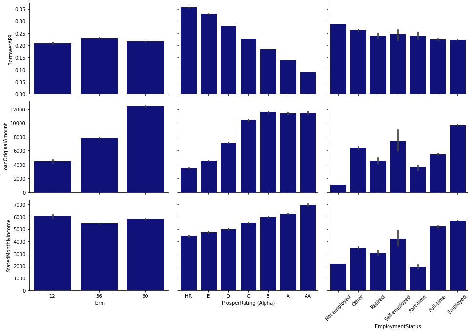

```python
plt.figure(figsize = (10, 10))
g = sb.PairGrid(data=df, y_vars=['BorrowerAPR', 'LoanOriginalAmount', 'StatedMonthlyIncome'],
                x_vars=['Term', 'ProsperRating (Alpha)', 'EmploymentStatus'],
                height=3, aspect = 1.5)
g.map(sb.barplot, color='darkblue')
plt.xticks(rotation=45);
```

Rating has negative relation with APR, the more the rating is, the less APR is. Large loan amounts tend to have longer terms and better ratings. Large loan amounts are mostly created by Employed borrowers. More monthly incomes have higher ratings.

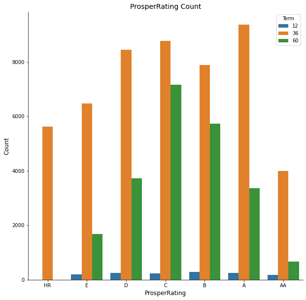

```python
plt.figure(figsize=(10,10))
sb.countplot(data=df, x='ProsperRating (Alpha)', hue='Term')
plt.title('ProsperRating Count', fontsize=14)
plt.xlabel('ProsperRating', fontsize=12)
plt.ylabel('Count', fontsize=12)
sb.despine()
```

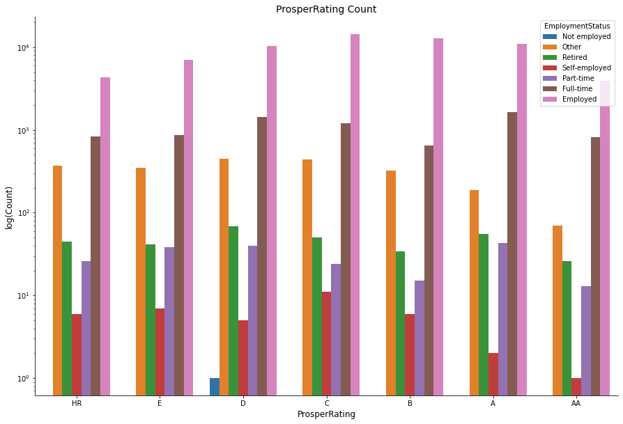

```python
plt.figure(figsize=(15,10))
sb.countplot(data=df, x='ProsperRating (Alpha)', hue='EmploymentStatus')
plt.title('ProsperRating Count', fontsize=14)
plt.xlabel('ProsperRating', fontsize=12)
plt.ylabel('log(Count)', fontsize=12)
plt.yscale('log')
sb.despine()
```

not-employed only appear in only D rating. self-employed have less mean rating.

### Talk about some of the relationships you observed in this part of the investigation. How did the feature(s) of interest vary with other features in the dataset?

> ```
>     APR has negative relation with ProsperRatings.
>     The APR has negative relation with MonthlyIncome.
>     The APR has negative relation with LoanAmount.
> ```

### Did you observe any interesting relationships between the other features (not the main feature(s) of interest)?

> ```
>     LoanAmount has positive correlation with MonthlyIncome.
>     LoanAmount has positive correlation with ProsperRatings. High loanAmounts tend to have higher ratings.
>     More MonthlyIncomes have higher ratings.
>     Large loanAmounts are made by employed borrowers.
>     36-months terms are the most popular across all ratings.
>     HR ratings have only 36-months terms.
>     not-employed and self-employed have less mean rating.
> ```

## Multivariate Exploration

> Create plots of three or more variables to investigate your data even further. Make sure that your investigations are justified, and follow from your work in the previous sections.

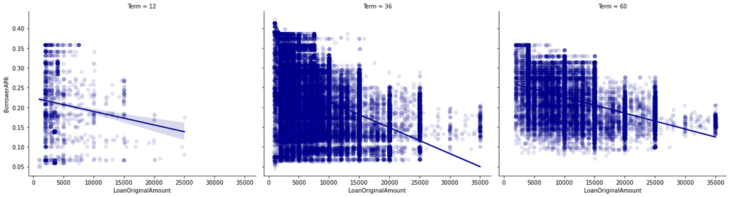

```python
plt.figure(figsize=(10,10))
g=sb.FacetGrid(data=df, col='Term', col_wrap=4, height=5, aspect=1.2)
g.map(sb.regplot, 'LoanOriginalAmount', 'BorrowerAPR', color='darkblue', x_jitter=100, scatter_kws={'alpha':0.1});
```

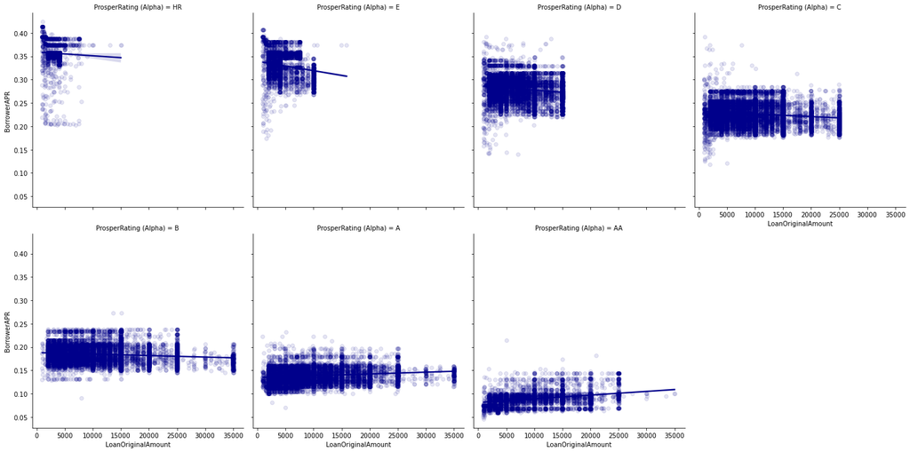

```python
plt.figure(figsize=(10,10))
g=sb.FacetGrid(data=df, col='ProsperRating (Alpha)', col_wrap=4, height=5, aspect=1)
g.map(sb.regplot, 'LoanOriginalAmount', 'BorrowerAPR', color='darkblue', x_jitter=100, scatter_kws={'alpha':0.1});
```

The Negative relation between the APR and loanAmount turns to be slightly positive in high ratings!

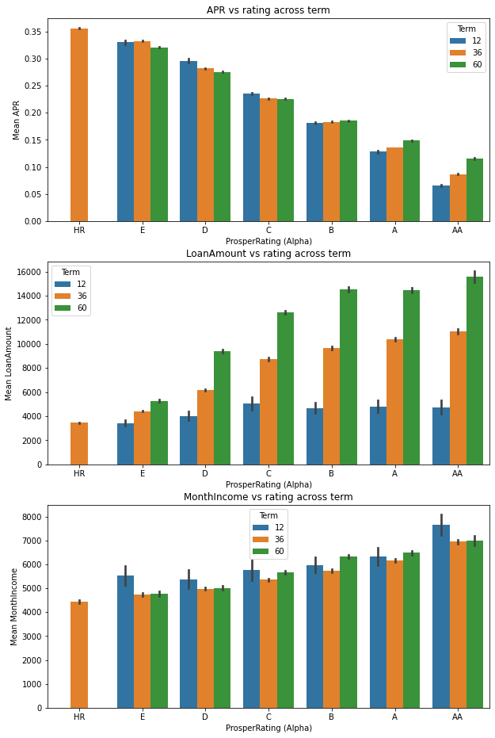

```python
plt.figure(figsize = (10,16))
plt.subplot(3,1,1)
sb.barplot(data=df, x='ProsperRating (Alpha)', y='BorrowerAPR', hue = 'Term')
plt.title('APR vs rating across term')
plt.ylabel('Mean APR')

plt.subplot(3,1,2)
sb.barplot(data=df, x='ProsperRating (Alpha)', y='LoanOriginalAmount', hue = 'Term')
plt.title('LoanAmount vs rating across term')
plt.ylabel('Mean LoanAmount')

plt.subplot(3,1,3)
sb.barplot(data=df, x='ProsperRating (Alpha)', y='StatedMonthlyIncome', hue = 'Term')
plt.title('MonthIncome vs rating across term')
plt.ylabel('Mean MonthIncome');
```

There is negative relation between APR and rating across all terms. There is positive relation between LoanAmount and rating for 36-months and 60-months terms but there is no change in 12-months term. For monthly income vs rating, the behaviour across all terms is quite similar with weak positive relation.

### Were there any interesting or surprising interactions between features?

> yes, APR vs LoanAmount's negative relation turning to be slightly positive in higher ratings.